# Wielowymiarowa Analiza Danych Stack Overflow Developer Survey 2025

### Wielowymiarowa Analiza Danych Stack Overflow Developer Survey 2025

# 1. Wstęp

## 1.1. Motywacja i cele

Celem projektu było przeprowadzenie wielowymiarowej analizy sektora IT w 2025 poprzez identyfikację, czynników wpływających na postawy deweloperów wobec narzędzi AI. Motywacją do przeprowadzenia analizy była chęć zrozumienia zależności pomiędzy konkretnymi segmentami branży IT, a postępującym rozwojem narzędzi AI.

```r
library(tidyverse)
library(FactoMineR)
library(factoextra)
library(psych)
library(GPArotation)
library(naniar)
library(mice)
library(corrplot)
library(Hmisc)
library(ggcorrplot)
library(knitr)
library(kableExtra)
library(tidytext)
library(stringr)
```

## 1.2. Opis problemu

Podjęty problem badawczo-biznesowy dotyczył potencjalnego zagrożenia dla rynku pracy IT polegającym na zastąpieniu pracowników przez narzędzia IA. Rozważono następujące pytania:

- Na jakie segmenty pod kątem wykorzystywanych technologii dzieli się rynek IT?
- W jakim stopniu przedstawiciele tych grup boją się zastąpienia przez AI?
- W jakim stopniu adoptują się do technologii AI?
- Jak oceniają jakość narzędzi AI w stosunku do ich segmentów technologicznych?

# 2. Opis danych

```r
podsumowanie_df <- function(dane) {
  n_rows <- nrow(dane)
  n_cols <- ncol(dane)
  ratio <- round(n_rows / n_cols, 1)
  size_mb <- round(as.numeric(object.size(dane)) / 1024^2, 2)
  completeness <- round(sum(!is.na(dane)) / (n_rows * n_cols) * 100, 1)

  dataset_info <- data.frame(
    Parametr = c("obserwacje", "zmienne", "reprezentatywność", "rozmiar", "kompletność"),
    Wartość = c(
      n_rows,
      n_cols,
      paste0(ratio, " : 1"),
      paste0(size_mb, " MB"),
      paste0(completeness, " %")
    )
  )

  return(dataset_info)
}


df <- read.csv("df.csv")

full_data_info <- podsumowanie_df(df)


df <- df %>%
  select(all_of(c(
  "WorkExp",
  "EdLevel",
  "JobSat",
  "AIThreat",
  "AISelect",
  "AISent",
  "AIAcc",
  "AIComplex",
  "AIAgents",
  "LearnCodeAI",
  "LanguageHaveWorkedWith",
  "DatabaseHaveWorkedWith",
  "WebframeHaveWorkedWith"
)))

bin_var_names <- c("LanguageHaveWorkedWith", "DatabaseHaveWorkedWith",
           "WebframeHaveWorkedWith"
)

df <- df[complete.cases(df[, bin_var_names]), ]

subset_data_info <- podsumowanie_df(df)
fina_data_info <- rbind(full_data_info, subset_data_info)
```

[Stack Overflow](https://stackoverflow.com/questions) to największa na świecie platforma społecznościowa dedykowana programistom oraz pasjonatom technologii. Użytkownicy mogą tam zadawać szczegółowe pytania techniczne, na które odpowiadają inni członkowie społeczności, tworząc tym samym ogromną bazę wiedzy. Od 2011 roku w ramach platformy corocznie organizowany jest Developer Survey. Ankieta ta zbiera dane od dziesiątek tysięcy specjalistów na temat ich ulubionych technologii, zarobków, preferowanych narzędzi oraz trendów w edukacji i pracy zdalnej. [Edycja 2025](https://survey.stackoverflow.co/2025/) jest wyjątkowa - po raz pierwszy w sposób szczególny skupiono się na rozwiązaniach AI.

[figure not shown]

```r
df_wide <- data.frame(
  Parametr = fina_data_info[1:5, 1],
  Oryginalne = fina_data_info[1:5, 2],
  Nowe = fina_data_info[6:10, 2]
)

kable(df_wide, col.names = c("Parametr", "Dane", "Próbka"), align = "lcc") %>%
  kable_styling(bootstrap_options = c("hover", "condensed"), full_width = F, position = "center", font_size = 17) %>%
  column_spec(1, bold = T, border_right = T, color = "#F48024") %>%
  column_spec(2:3, bold = T, color = "white", background = "#F48024")
```

| Parametr | Dane | Próbka |
| --- | --- | --- |
| obserwacje | 49191 | 20319 |
| zmienne | 172 | 13 |
| reprezentatywność | 286 : 1 | 1563 : 1 |
| rozmiar | 88.86 MB | 4.78 MB |
| kompletność | 47.6 % | 97.3 % |

Wykorzystane dane pochodzą z oficjalnej strony [Developer Survey](https://survey.stackoverflow.co/). Na ankietę składająca się z 62 pytań odpowiedziało 49191 respondentów. Ze względu na dobrowolny charakter wszystkich pytań oraz warunkowy schemat ankiety kompletność danych jest stosunkowo niska i wynosi ok. 48%. Z racji na tą zależność po wstępnym obejrzeniu zbioru danych, zostały usunięte ankiety osób, które nie określiły z jakich technologii korzystają (języki programowania, bazy danych, frameworki webowe). Dokonano również selekcji pytań. W efekcie baza danych została zmniejszona do 20319 obserwacji z 97% kompletnością wartości. Do realizacji celu projektu wybrano 13 adekwatnych zmiennych spośród 172. Oprócz pytań dotyczących sztucznej inteligencji wzięte pod uwagę zostały również pytania o poziom edukacji, doświadczenia zawodowego, satysfakcji z pracy oraz informacje o wykorzystywanych technologiach.

**Skład zmiennych wybranych do analizy oraz odpowiadające im pytania ankietowe:**

- “WorkExp” Ile masz lat doświadczenia zawodowego?
- “EdLevel” Jaki jest twój poziom wykształcenia formalnego?
- “JobSat” Jaki odczuwasz poziom satysfakcji z roli dewelopera?
- “AIThreat” Czy AI to zagrożenie dla pracy?
- “AISelect” Czy używasz narzędzi AI w pracy?
- “AISent” Jaki jest twój stosunek do używania AI?
- “AIAcc” Jakie jest twoje zaufanie do dokładności AI?
- “AIComplex” Jak oceniasz radzenie sobie AI ze złożonymi zadaniami?
- “AIAgents” Czy używasz agentów AI?

# 3. Obróbka zmiennych

## 3.1. Tworzenie nowych zmiennych

W analizowanej ankiecie pytania dotyczące wykorzystywanych technologii (pytania osobno o języki programowania, frameworki webowe oraz systemy baz danych były pytaniami wielokrotnego wyboru. W zbiorze danych odpowiedzi te występowały w postaci nazw technologii które były oddzielone od siebie średnikami, osobno dla każdej kategorii. W celu dostosowania danych do analizy zastosowano kodowanie binarne. Przekształcono każdą technologię na zmienną binarną (*dummy variable*) w której 1 oznacza znajomość technologii a 0 brak znajomości. W wyniku przekształceń uzyskano 100 zmiennych które reprezentują 100 unikalnych technologii.

Pytania dotyczące stosunku respondeta do narzędzi AI a także te definiujące jego profil społeczny i zawodowy występowały w skali Likerta. Zastosowano wobec nich kodowanie polegające na zastąpieniu wartości tekstowych na zmienne kategoryczne uporządkowane. Zmienne ciągłe (np. doświadczenie zawodowe) przekształcono na zmienne kategoryczne uporządkowane, w procesie tym obsłużono również wartości odstające, definiując je jako nierealne/niereprezentatywne (np. 70 lat doświadczenia zawodowego) i potraktowano je jako braki danych.

```r
# KODOWANIE ZMIENNYCH BINARNYCH
bin_tech_column <- function(data, column_name, prefix) {
  data %>%
    select(all_of(column_name)) %>%
    mutate(id = row_number()) %>%
    separate_rows(!!sym(column_name), sep = ";") %>%
    mutate(!!sym(column_name) := trimws(!!sym(column_name)),
           value = 1) %>%
    pivot_wider(
      names_from = !!sym(column_name),
      values_from = value,
      values_fill = 0,
      names_prefix = paste0(prefix, "_")
    ) %>%
    select(-id)
}

df <- df %>%
  select(-all_of(bin_var_names)) %>%
  cbind(
    bin_tech_column(df, "WebframeHaveWorkedWith", "web"),
    bin_tech_column(df, "DatabaseHaveWorkedWith", "db"),
    bin_tech_column(df, "LanguageHaveWorkedWith", "lang")
  )
```

```r
# KODOWANIE ZMIENNYCH JAKOŚCIOWYCH UPORZĄDKOWANYCH
df <- df %>%
  mutate(
    AISelect = case_when(
      AISelect == "Yes, I use AI tools daily" ~ 4,
      AISelect == "Yes, I use AI tools weekly" ~ 3,
      AISelect == "Yes, I use AI tools monthly or infrequently" ~ 2,
      AISelect == "No, but I plan to soon" ~ 1,
      AISelect == "No, and I don't plan to" ~ 0,
      TRUE ~ NA_real_
    ),

    AIAcc = case_when(
      AIAcc == "Highly trust" ~ 5,
      AIAcc == "Somewhat trust" ~ 4,
      AIAcc == "Neither trust nor distrust" ~ 3,
      AIAcc == "Somewhat distrust" ~ 2,
      AIAcc == "Highly distrust" ~ 1,
      TRUE ~ NA_real_
    ),

    AISent = case_when(
      AISent == "Very favorable" ~ 5,
      AISent == "Favorable" ~ 4,
      AISent %in% c("Indifferent", "Unsure") ~ 3,
      AISent == "Unfavorable" ~ 2,
      AISent == "Very unfavorable" ~ 1,
      TRUE ~ NA_real_
    ),

    AIComplex = case_when(
      AIComplex == "Very well at handling complex tasks" ~ 5,
      AIComplex == "Good, but not great at handling complex tasks" ~ 4,
      AIComplex %in% c("Neither good or bad at handling complex tasks",
                       "I don't use AI tools for complex tasks / I don't know") ~ 3,
      AIComplex == "Bad at handling complex tasks" ~ 2,
      AIComplex == "Very poor at handling complex tasks" ~ 1,
      TRUE ~ NA_real_
    ),

    AIAgents = case_when(
      AIAgents == "Yes, I use AI agents at work daily" ~ 5,
      AIAgents == "Yes, I use AI agents at work weekly" ~ 4,
      AIAgents == "Yes, I use AI agents at work monthly or infrequently" ~ 3,
      AIAgents == "No, I use AI exclusively in copilot/autocomplete mode" ~ 2,
      AIAgents == "No, but I plan to" ~ 1,
      AIAgents == "No, and I don't plan to" ~ 0,
      TRUE ~ NA_real_
    ),

    AIThreat = case_when(
      AIThreat == "Yes" ~ 2,
      AIThreat == "I'm not sure" ~ 1,
      AIThreat == "No" ~ 0,
      TRUE ~ NA_real_
    ),

    EdLevel = case_when(
      EdLevel == "Primary/elementary school" ~ 1,
      EdLevel == "Secondary school (e.g. American high school, German Realschule or Gymnasium, etc.)" ~ 2,
      EdLevel == "Some college/university study without earning a degree" ~ 3,
      EdLevel == "Associate degree (A.A., A.S., etc.)" ~ 4,
      EdLevel == "Bachelor’s degree (B.A., B.S., B.Eng., etc.)" ~ 5,
      EdLevel == "Master’s degree (M.A., M.S., M.Eng., MBA, etc.)" ~ 6,
      EdLevel == "Professional degree (JD, MD, Ph.D, Ed.D, etc.)" ~ 7,
      TRUE ~ NA_real_
    ),

    LearnCodeAI = case_when(
      LearnCodeAI == "No, I didn't spend time learning in the past year" ~ 0,
      grepl("^No, I learned something that was not related to AI", LearnCodeAI) ~ 1,
      LearnCodeAI == "Yes, I learned how to use AI-enabled tools for my personal curiosity and/or hobbies" ~ 2,
      LearnCodeAI == "Yes, I learned how to use AI-enabled tools required for my job or to benefit my career" ~ 3,
      TRUE ~ NA_real_
    ),

    WorkExp = case_when(
      WorkExp <= 2  ~ 0,
      WorkExp <= 5  ~ 1,
      WorkExp <= 10 ~ 2,
      WorkExp <= 20 ~ 3,
      WorkExp <= 50 ~ 4,
      TRUE ~ NA_real_
    ),

    JobSat = case_when(
      JobSat <= 2  ~ 0,
      JobSat <= 4  ~ 1,
      JobSat <= 6  ~ 2,
      JobSat <= 8  ~ 3,
      JobSat <= 10 ~ 4,
      TRUE ~ NA_real_
    )
  )
```

## 3.2. Standaryzacja i normalizacja

Dane dotyczące technologii są danymi binarnymi. Dla zastosowanych metod nie jest konieczna standaryzacja i normalizacja. Dane kategoryczne uporządkowane zostały przetwarzane w dalszych punktach przez macierz polichoryczną co zastąpiło wspomniane operacje.

# 4. Analiza eksploracyjna danych

## 4.1. Podstawowe statystyki opisowe

```r
# Obliczanie liczby technologii
df <- df %>%
  mutate(
    num_langs = rowSums(select(., starts_with("lang_")), na.rm = TRUE),
    num_dbs   = rowSums(select(., starts_with("db_")), na.rm = TRUE),
    num_webs  = rowSums(select(., starts_with("web_")), na.rm = TRUE)
  )

# Obliczanie statystyk
summary_by_category <- df %>%
  select(num_langs, num_dbs, num_webs) %>%
  pivot_longer(cols = everything(),
               names_to = "Kategoria",
               values_to = "Liczba") %>%
  group_by(Kategoria) %>%
  summarise(
    Q1 = quantile(Liczba, 0.25, na.rm = TRUE),
    Mediana = median(Liczba, na.rm = TRUE),
    Q3 = quantile(Liczba, 0.75, na.rm = TRUE)
  )

summary_by_category$Kategoria <- c(
  "Liczba znanych systemów baz danych",
  "Liczba znanych języków programowania",
  "Liczba znanych frameworków webowych"
)

# Tabela statystyk
summary_by_category %>%
  kable(
    col.names = c("Kategoria", "Q1", "Mediana", "Q3"),
    caption = "Statystyki dla danych o technologiach",
    align = "lccccc"
  ) %>%
  kable_styling(
    bootstrap_options = c("striped", "hover"),
    full_width = F
  ) %>%
  column_spec(1, bold = T, color = "#F48024")
```

Statystyki dla danych o technologiach

| Kategoria | Q1 | Mediana | Q3 |
| --- | --- | --- | --- |
| Liczba znanych systemów baz danych | 2 | 3 | 5 |
| Liczba znanych języków programowania | 5 | 6 | 8 |
| Liczba znanych frameworków webowych | 2 | 3 | 5 |

```r
# Statystyki dla zmiennych jakościowych uporządkowanych
tabela_statystyk <- df %>%
  select(AISelect, AIAcc, AISent, AIComplex, AIAgents, AIThreat, EdLevel, LearnCodeAI, WorkExp, JobSat) %>%
  pivot_longer(cols = everything(), names_to = "Zmienna", values_to = "Wartosc") %>%
  group_by(Zmienna) %>%
  summarise(
    Min = min(Wartosc, na.rm = TRUE),
    Q1 = quantile(Wartosc, 0.25, na.rm = TRUE),
    Mediana = median(Wartosc, na.rm = TRUE),
    Q3 = quantile(Wartosc, 0.75, na.rm = TRUE),
    Max = max(Wartosc, na.rm = TRUE)
  )

# 2. Tabela dopasowana do zawartości (full_width = F)
tabela_statystyk %>%
  kable(
    col.names = c("Zmienna", "Min", "Q1", "Mediana", "Q3", "Maks"),
    caption = "Statystyki dla danych jakościowych uporządkowanych",
    align = "lccccc"
  ) %>%
  kable_styling(
    bootstrap_options = c("striped", "hover"),
    full_width = F
  ) %>%
  column_spec(1, bold = T, color = "#F48024")
```

Statystyki dla danych jakościowych uporządkowanych

| Zmienna | Min | Q1 | Mediana | Q3 | Maks |
| --- | --- | --- | --- | --- | --- |
| AIAcc | 1 | 2 | 3 | 4 | 5 |
| AIAgents | 0 | 0 | 1 | 4 | 5 |
| AIComplex | 1 | 2 | 3 | 4 | 5 |
| AISelect | 0 | 2 | 4 | 4 | 4 |
| AISent | 1 | 3 | 4 | 4 | 5 |
| AIThreat | 0 | 0 | 0 | 1 | 2 |
| EdLevel | 1 | 5 | 5 | 6 | 7 |
| JobSat | 0 | 2 | 3 | 3 | 4 |
| LearnCodeAI | 0 | 1 | 2 | 3 | 3 |
| WorkExp | 0 | 1 | 3 | 3 | 4 |

Analiza podstawowych statystyk dla 10 pytań, które zakodowane zostały jako zmienne kategoryczne uporządkowane w skład których wchodzą także zmienne w skali Likerta ujawniła sporo wniosków dotyczących respondentów. Najsilniejsze trendy widać w zmiennych dotyczących ogólnego nastawienia i częstotliwości pracy z nową technologią. Zmienna AISent , odpowiadająca na pytanie o ogólny stosunek do AI, posiada medianę na poziomie 4, co oznacza, że typowy deweloper ocenia tę technologię jako pozytywną. Współgra to z wynikiem zmiennej AISelect (częstotliwość użycia), gdzie mediana wynosząca 4 wskazuje na codzienne wykorzystywanie narzędzi AI w pracy. Co niezwykle istotne, zmienna AIThreat (pytanie o zagrożenie dla pracy ze strony AI) ma medianę 0, co oznacza stanowczą odpowiedź “nie”. Sugeruje to, że deweloperzy traktują AI jako codzienne wsparcie, a nie konkurencję. Mimo wysokiego entuzjazmu, programiści zachowują dystans do AI w kwestiach technicznych.

Zmienne AIAcc (zaufanie do dokładności wyników) oraz AIComplex (ocena radzenia sobie ze złożonymi zadaniami) mają mediany równe 3. Oznacza to postawę neutralną („ani ufam, ani nie ufam” oraz „ani dobrze, ani źle”). Oznacza to, że typowy respondent nie ufa AI bezkrytycznie. Podobnie sytuacja wygląda przy AIAgents (używanie agentów AI), gdzie mediana 1 wskazuje na etap planowania wdrożenia w najbliższej przyszłości, co pokazuje, że rok 2025 to czas przejścia od prostych asystentów kodu do bardziej złożonych systemów agentowych. Statystyczny obraz dopełniają zmienne demograficzne i zawodowe, które świadczą o wysokim profesjonalizmie badanej grupy. Zmienna EdLevel z medianą 5 wskazuje, że typowy respondent posiada tytuł licencjata lub inżyniera. W połączeniu z medianą 3 dla WorkExp (co w oznacza staż między 11 a 20 lat), widzimy, że ankieta dotarła do dojrzałych, doświadczonych pracowników. Grupa ta jest przy tym zadowolona ze swojej ścieżki zawodowej JobSat z medianą 3 (odpowiednik punktacji 7–8 w skali 10-stopniowej) świadczy o wysokiej satysfakcji z pracy.

Warto zwrócić uwagę na zmienną LearnCodeAI, która pyta o to, czy i w jakim celu deweloper uczył się programowania z AI w ostatnim roku. Mediana na poziomie 2 oznacza, że statystyczny programista podjął wysiłek nauki z własnej ciekawości lub hobbystycznie. Choć codzienne użycie jest wysokie (mediana 4), to systematyczne szkolenie ukierunkowane stricte na rozwój kariery (wartość 3) nie stało się jeszcze standardem dla większości, co sugeruje ogromne pole do wzrostu w obszarze profesjonalnej edukacji AI.

## 4.2. Analiza rozkładów

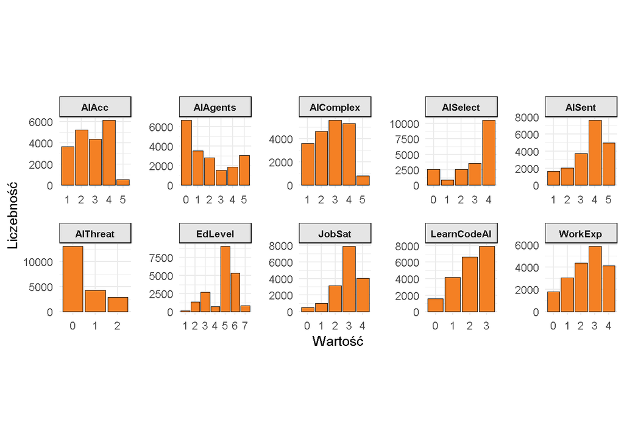

```r
# Rozkłady dla zmiennych jakościowych uporządkowanych
df %>%
  select(AISelect, AIAcc, AISent, AIComplex, AIAgents, AIThreat, EdLevel, LearnCodeAI, WorkExp, JobSat) %>%
  pivot_longer(cols = everything(), names_to = "Zmienna", values_to = "Wartosc") %>%
  filter(!is.na(Wartosc)) %>%
  ggplot(aes(x = factor(Wartosc))) +
  geom_bar(fill = "#F48024", color = "black", size = 0.2) +
  facet_wrap(~Zmienna, scales = "free", ncol = 5) +
  theme_minimal() +
  labs(
    x = "Wartość",
    y = "Liczebność"
  ) +
  theme(
    aspect.ratio = 1,
    strip.background = element_rect(fill = "grey90"),
    strip.text = element_text(face = "bold", size = 8),
    panel.spacing = unit(1, "lines")
  )
```

## 4.3. Analiza korelacji

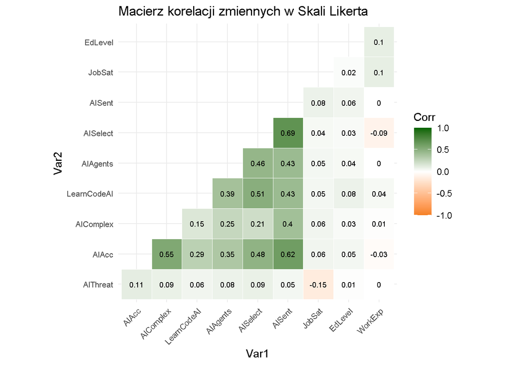

```r
# Wybór zmiennych w Skali Likerta
likert_vars <- df %>%
  select(AISelect, AIAcc, AISent, AIComplex, AIAgents, AIThreat, EdLevel, LearnCodeAI, WorkExp, JobSat)

# Macierz korrelacji
cor_pearson <- cor(likert_vars,
                   method = "pearson",
                   use = "pairwise.complete.obs")

ggcorrplot(cor_pearson,
           hc.order = TRUE,
           type = "lower",
           lab = TRUE,
           lab_size = 2.5,
           outline.color = "white",
           colors = c("#F48024", "white", "darkgreen"),
           title = "Macierz korelacji zmiennych w Skali Likerta") +
  theme_minimal() +
  theme(
    axis.text.x = element_text(angle = 45, vjust = 1, hjust = 1, size = 8),
    axis.text.y = element_text(size = 8)
  )
```

Prezentowana macierz korelacji Pearsona stanowi punkt wyjścia dla eksploracyjnej analizy czynnikowej, wizualizując siłę i kierunek powiązań między badanymi zmiennymi. Dominacja koloru zielonego w dolnym lewym rogu macierzy wskazuje na istnienie silnych, dodatnich korelacji w obszarze postaw wobec AI, co potwierdza zasadność poszukiwania ukrytych wymiarów wspólnych.

Najsilniejsze korelacje w zbiorze danych koncentrują się wokół zmiennych nastawienie, użytkowanie oraz zaufanie do AI. Najsilniejsza zależność w całej macierzy, wynosząca 0.69 dotyczy nastawienia do AI oraz użycia technologii AI. Wskazuje ona, że deweloperzy o pozytywnym stosunku do AI są najbardziej skłonni do wdrażania tych narzędzi w swojej codziennej rutynie pracy. Bardzo silna korelacja dodatnia nastawienia do AI oraz zaufania (AIAcc) na poziomie 0.62 dowodzi, że ogólny entuzjazm wobec technologii jest ściśle powiązany z subiektywną oceną jej dokładności.

## 4.4. Analiza braków danych

Skala braków danych w badanym zbiorze jest zróżnicowana, jednak dla większości zmiennych utrzymuje się na niskim poziomie poniżej 5%. Taki poziom braków danych można efektywnie uzupełnić metodami imputacji. Jedyną zmienną, która znacznie wyróżnia się na tle innych pod kątem ilości brakujących wartości jest poziom satysfakcji z brakami wynoszącymi 18,57%. Jest to bardzo duża ilość sugerująca odrzucenie zmiennej, lecz zdecydowano o pozostawieniu jej ze świadomością, że jakość tej zmiennej po imputacji obniży się.

```r
# Podział datasetu wg. przyszłej metody
df_efa <- df %>%
  select(!starts_with(c("web_", "db_", "lang_")))

df_mca <- df %>%
  select(starts_with(c("web_", "db_", "lang_")))

tabela_brakow <- data.frame(
  Zmienna = colnames(df_efa),
  Liczba_NA = colSums(is.na(df_efa)),
  Procent_NA = round(colMeans(is.na(df_efa)) * 100, 2)
)

tabela_brakow <- tabela_brakow[order(-tabela_brakow$Liczba_NA), ]

tabela_brakow %>%
  kable(
    col.names = c("Nazwa zmiennej", "Liczba braków (N)", "Udział braków (%)"),
    caption = "Analiza braków",
    align = "lcc",
    row.names = FALSE
  ) %>%
  kable_styling(
    bootstrap_options = c("striped", "hover", "condensed"),
    full_width = F,
    position = "left"
  ) %>%
  column_spec(1, bold = T, color = "#F48024")
```

Analiza braków

| Nazwa zmiennej | Liczba braków (N) | Udział braków (%) |
| --- | --- | --- |
| JobSat | 3774 | 18.57 |
| WorkExp | 1122 | 5.52 |
| AIAgents | 772 | 3.80 |
| AIAcc | 378 | 1.86 |
| AIComplex | 376 | 1.85 |
| AISent | 322 | 1.58 |
| AISelect | 264 | 1.30 |
| EdLevel | 243 | 1.20 |
| AIThreat | 138 | 0.68 |
| LearnCodeAI | 35 | 0.17 |
| num_langs | 0 | 0.00 |
| num_dbs | 0 | 0.00 |
| num_webs | 0 | 0.00 |

**MCAR - test zależności braków danych**

```r
# TEST ZALEŻNOŚCI BRAKÓW DANYCH
mcar_result <- mcar_test(df_efa)
mcar_result
```

```
## # A tibble: 1 × 4
##   statistic    df p.value missing.patterns
##       <dbl> <dbl>   <dbl>            <int>
## 1     3960.   745       0               80
```

Wartość p-value równa 0 oznacza odrzucenie hipotezy zerowej mówiącej o tym, że dane są brakujące całkowicie losowo (missing completely at random). Oznacza to, że braki w danych mają charakter nielosowy. Istnieje systematyczna zależność między występowaniem braków a wartościami innych zmiennych w zbiorze.

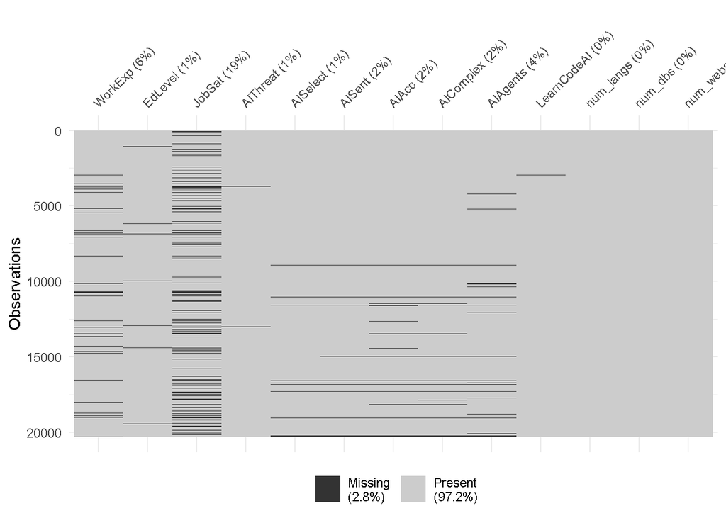

```r
vis_miss(df_efa, warn_large_data = FALSE)
```

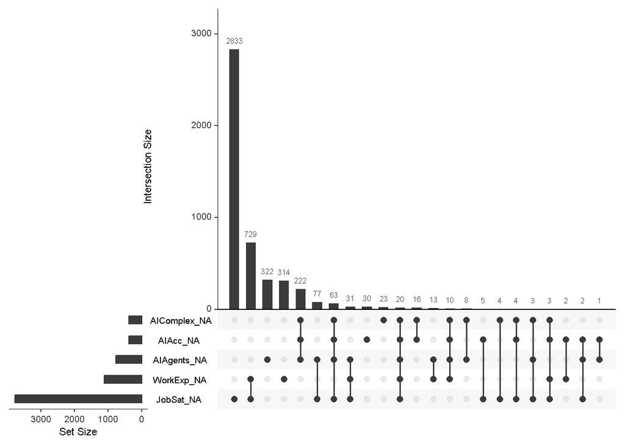

```r
gg_miss_upset(df_efa)
```

## 4.5. Analiza obserwacji odstających

W badanym zbiorze danych zlokalizowano wartości odstające w zmiennej dotyczącej doświadczenia zawodowego, wynikające z wielkości powyżej 50 lat doświadczenia, lecz już na poziomie przekodowania zmiennych obserwacje te zostały usunięte. Poza tą zmienną nie stwierdzono obecności istotnych obserwacji odstających. Brak klasycznych outlierów wynika bezpośrednio ze struktury wybranych zmiennych. Większość zmiennych została zmierzona na skali Likerta. Ponieważ odpowiedzi są ograniczone do zamkniętego, wąskiego przedziału występowanie outlierów jest niemożliwe. Podobnie jest w przypadku innych zmiennych kategorycznych oraz zmiennych binarnych.

# 5. Czyszczenie danych

## 5.1. Obsługa braków wartości

Proces uzupełniania braków danych w projekcie został przeprowadzony przy użyciu zaawansowanego algorytmu MICE, co było podyktowane nielosowym charakterem brakujących informacji zidentyfikowanym w teście Little’a. Zastosowana procedura opiera się na metodzie imputacji wielokrotnej, która zamiast zastępować brak jedną wartością, tworzy kilka kompletnych zbiorów danych, co pozwala na zachowanie naturalnej zmienności i korelacji między zmiennymi. Jest to szczególnie istotne dla zmiennej odnoszącej się do satysfakcji z pracy, gdzie skala braków wynosiła aż 18.57%.

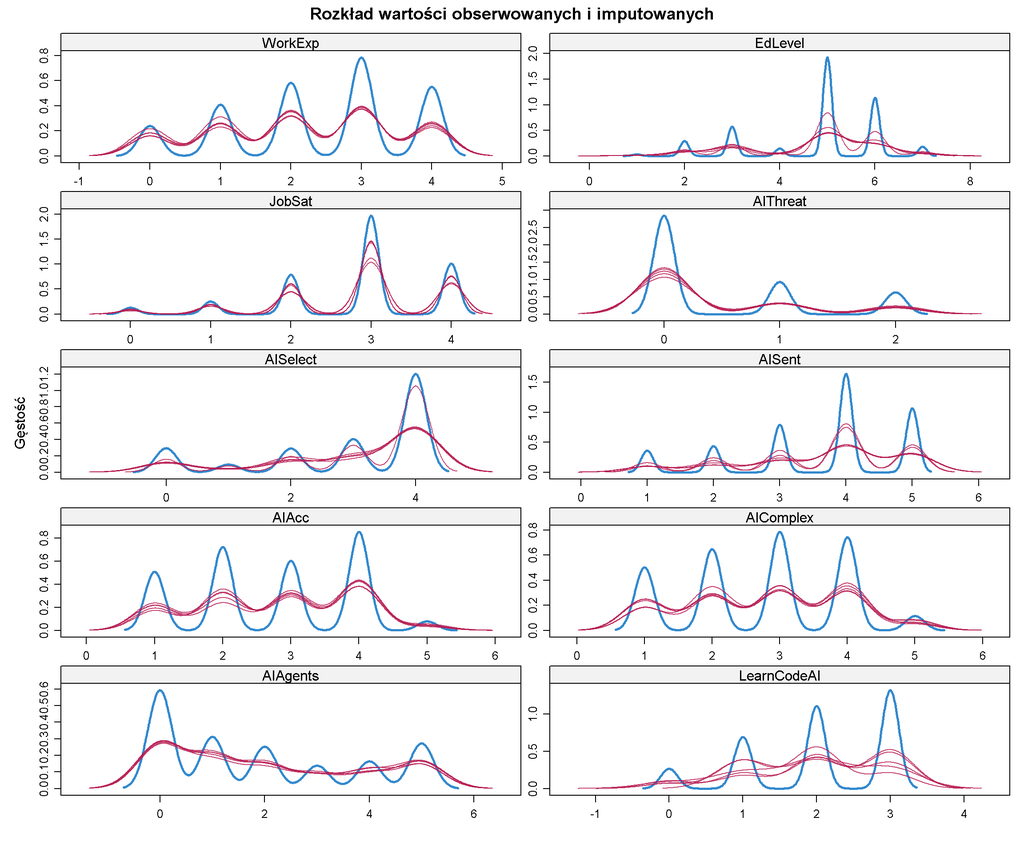

```r
densityplot(mice_result,
            ~ WorkExp + EdLevel + JobSat + AIThreat + AISelect + AISent + AIAcc + AIComplex + AIAgents + LearnCodeAI,
            layout = c(2, 5),
            main = "Rozkład wartości obserwowanych i imputowanych")
```

## 5.2. Obsługa obserwacji odstających

Obsługa obserwacji odstających została opisana w punkcie 4.5..

# 6. Metodyka

## 6.1. Wielowymiarowa Analiza Korespondencji

W celu pogrupowania technologii i wyodrębnienia z nich spójnych grup zastosowano Wielowymiarową Analizę Korespondencji (MCA). Została ona wybrana, ponieważ bardzo dobrze wpisuje się w charakter danych kategorycznych binarnych i porządkowych. Metoda MCA pozwala na stworzenie mapy percepcyjnej, na której odległości między punktami reprezentują podobieństwo technologii.

W celu osiągnięcia wyżej wymienionych efektów, ostatecznie do analizy wybrano zmienne binarne powstałe na skutek przekształcenia zmiennych:

- “LanguageHaveWorkedWith” (Z jakich języków programowania korzystasz?)
- “DatabaseHaveWorkedWith” (Z jakich bazy danych korzystasz?)
- “WebframeHaveWorkedWith” (Z jakich frameworków webowych korzystasz?)

Zachowano jedynie te technologie, które są używane przez co najmniej 1% badanej populacji. Pozwoliło to na zredukowanie liczby analizowanych narzędzi ze 100 do 92 najistotniejszych rynkowo pozycji. Ostatecznym wynikiem jest dwuwymiarowy wykres zmiennych, na którym technologie współwystępujące ze sobą w rzeczywistych projektach znajdują się bliżej siebie.

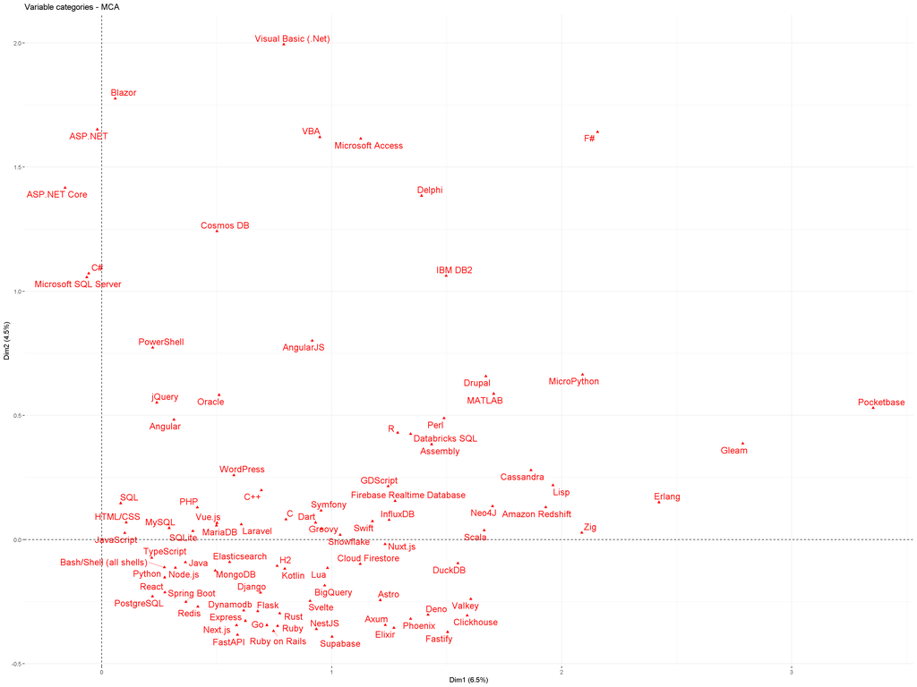

```r
run_clean_mca <- function(data, threshold = 0.300) {
  tech_data <- data %>% select(starts_with("lang_"), starts_with("db_"), starts_with("web_"))
  tech_data <- tech_data %>% select(-contains("_NA"))

  n_min <- nrow(tech_data) * threshold
  common_cols <- names(which(colSums(tech_data == 1) > n_min))

  tech_filtered <- tech_data %>% select(all_of(common_cols))


  row_sums <- rowSums(tech_filtered)
  tech_final <- tech_filtered[row_sums > 0, ]


  tech_final <- tech_final %>% mutate(across(everything(), as.factor))

  res.mca <- MCA(tech_final, graph = FALSE, ncp = 5)

  return(list(model = res.mca, data = tech_final))
}


mca_results <- run_clean_mca(df_mca, threshold = 0.01)
posiadane_tech <- grep("_1$", rownames(mca_results$model$var$nm), value = TRUE)


wszystkie_kategorie <- rownames(mca_results$model$var$coord)


tylko_posiadane <- wszystkie_kategorie[grep("_1$", wszystkie_kategorie)]
contribs <- mca_results$model$var$contrib
nasze_contribs <- contribs[rownames(contribs) %in% tylko_posiadane, ]
top_30_z_listy <- names(sort(nasze_contribs[,1] + nasze_contribs[,2], decreasing = TRUE)[1:98])


#Model tylko do wykresu
model_do_wykresu <- mca_results$model
rownames(model_do_wykresu$var$coord) <- gsub("^lang_|^db_|^web_|_1$", "", rownames(model_do_wykresu$var$coord))
top_czyste_nazwy <- gsub("^lang_|^db_|^web_|_1$", "", top_30_z_listy)

fviz_mca_var(model_do_wykresu,
             choice = "var.cat",
             select.var = list(name = top_czyste_nazwy),
             labelsize = 5,
             axes = c(1, 2),
             repel = TRUE,
             ggtheme = theme_minimal())
```

Niska wartość wyjaśnianej wariancji (łącznie 11% dla dwóch osi) jest typowa dla MCA przy tak dużej liczbie zmiennych. Potwierdza to ogromne rozproszenie i różnorodność narzędzi używanych przez deweloperów w 2025 roku. Mimo to, odległości na mapie dobrze tłumaczą strukturę.

Przekształcono wyniki MCA w segmentację technologii za pomocą klastrowania hierarchicznego. Przeprowadzono ten proces, aby zamienić mapę punktów w konkretne, logiczne grupy widoczne na dendrogramie. Wykorzystano metodę klastrowania Warda, która dąży do minimalizacji wariancji wewnątrz klastrów.

## 6.2. Klastrowanie Hierarchiczne na wynikach MCA

W celu wyodrębnienia spójnych klastrów technologicznych i nazwania ich przeprowadzono Klastrowanie Hierarchyczne (HC) na wynikach uzyskanych dzięki redukcji wymiarów MCA.

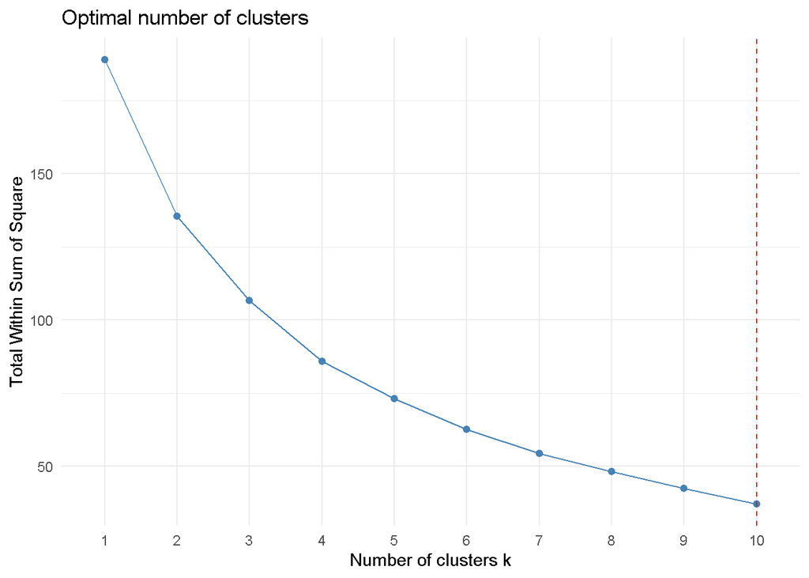

```r
wszystkie_kategorie <- rownames(mca_results$model$var$coord)
posiadane_tech <- grep("_1$", wszystkie_kategorie, value = TRUE)
coords_posiadane <- mca_results$model$var$coord[posiadane_tech, ]

fviz_nbclust(coords_posiadane,
             FUNcluster = hcut,
             method = "wss",
             hc_method = "ward.D2") +
  geom_vline(xintercept = 10, linetype = 2, color = "red") +
  theme_minimal()
```

W celu wyznaczenia optymalnej liczby klastrów technologicznych przeprowadzono analizę metodą łokcia (WSS). Wykres nie zobrazował jednoznacznego przegięcia na wykresie. W celu wyodrębninienia jak najbardziej specjalistyczhc grup technologi zdecydowano o przyjęciu 10 klastrów.

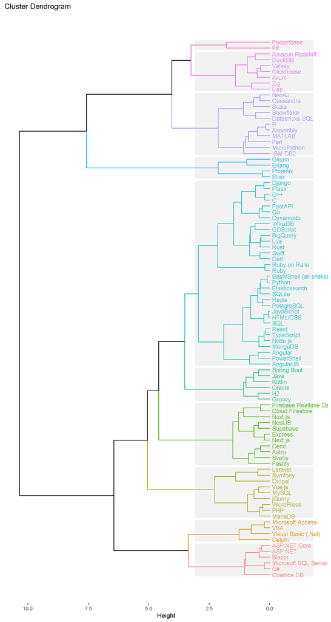

```r
# HC na technologiach z wyników MCA



rownames(coords_posiadane) <- gsub("^lang_|^db_|^web_|_1$", "", rownames(coords_posiadane))

hc_tech <- hclust(dist(coords_posiadane), method = "ward.D2")

fviz_dend(hc_tech,
          k = 10,
          cex = 0.7,
          horiz = TRUE,
          rect = TRUE,
          rect_fill = TRUE)
```

Na podstawie analizy wykresu wyodrębniono:

**Ekosystem .NET - Microsoft** (czerwony)

Zbiór technologii rozwijanych przez firmę Microsoft do budowania nowoczesnych aplikacji biznesowych i serwerowych. Są to standardowe rozwiązania w dużych firmach korzystających z rozwiązań tej marki.

**Technologie Microsoft Legacy i Desktop** (pomarańczowy)

Starsze technologie (tzw. legacy) oraz narzędzia do tworzenia aplikacji instalowanych bezpośrednio na komputerach (desktopowych). Często wykorzystywane do automatyzacji biurowej i utrzymania systemów sprzed lat.

**Web Development PHP i systemy CMS** (oliwkowy)

Klasyczny segment tworzenia stron internetowych. Obejmuje najpopularniejszy język stron WWW (PHP) oraz gotowe systemy do zarządzania treścią (jak WordPress), które napędzają ogromną część dzisiejszego internetu.

**Nowoczesne frameworki JavaScript - fullstack** (jasnozielony)

Grupa najnowszych narzędzi służących do budowania dynamicznych i szybkich aplikacji internetowych. Są to technologie typu “wszystko w jednym”, pozwalające tworzyć zarówno to, co widzi użytkownik, jak i to, co dzieje się na serwerze.

**Technologie korporacyjne Java - JVM** (morska zielień)

Rozwiązania oparte na języku Java, wykorzystywane przez największe instytucje (banki, korporacje). Służą do budowania ogromnych, bezpiecznych systemów, które muszą obsługiwać miliony operacji.

**Technologie ogólnego przeznaczenia** (turkusowy)

Główne technologie rynku IT. Obejmują najpopularniejsze bazy danych (jak PostgreSQL), języki systemowe (C, C++) oraz najbardziej uniwersalne narzędzia, które są podstawą pracy niemal każdego programisty.

**Systemy wysokiej wydajności i programowanie funkcyjne** (niebieski)

Specjalistyczna grupa narzędzi do budowania systemów, które nigdy nie mogą się “zawiesić”. Stosowane w telekomunikacji, systemach czatów i wszędzie tam, gdzie kluczowa jest obsługa wielu użytkowników naraz.

**Analityka danych i Big Data** (fioletowy)

Technologie służące do przetwarzania i analizowania ogromnych zbiorów informacji. Wykorzystywane przez analityków danych, statystyków oraz przy tworzeniu sztucznej inteligencji.

**Specjalistyczne bazy danych i języki niszowe** (różowy)

Nowoczesne, bardzo szybkie bazy danych do zadań specjalnych (np. analityka w czasie rzeczywistym) oraz języki programowania, które zyskują popularność dzięki swojej efektywności w konkretnych problemach technicznych.

## 6.3. Hierarchiczne Klastrowanie na Składowych Głównych wyniku MCA

W celu przypisania konkretnej grupy technologicznej do konkretnych respondetów zastosowano Hierarchiczne Klastrowanie na Składowych Głównych (HCPC). Wyodrębniono 10 klastrów sugerując się wynikami uzyskanymi w poprzednim punkcie. W przeciwieństwie do metody HC gdzie klastrowano technologie, metoda HCPC dokonuje klastrowania bezpośrednio na respondentach ankiety biorąc pod uwagę analizę korespondencji technologii. Tabela przedstawia klastry wynikowe HCPC wraz ich liczebnością oraz 3 technologiami które miały największy udział w definiowaniu klastra. Udział jest tu rozmiany przez wartość v-test. Im wyższa wartość dodatnia, tym bardziej dana technologia reprezentowana w tym klastrze w porównaniu do całego zbioru danych. Nazwy klastrów określono na podstawie technologii.

```r
res.hcpc <- HCPC(mca_results$model,
                 nb.clust = 10,
                 method = "ward",
                 graph = FALSE)

df_liczebnosc <- as.data.frame(table(res.hcpc$data.clust$clust))
colnames(df_liczebnosc) <- c("clust_id", "Liczebność")


get_cluster_techs <- function(hcpc_obj, cluster_id) {
  df <- as.data.frame(hcpc_obj$desc.var$category[[as.character(cluster_id)]])
  techs <- rownames(df) %>%
    sub("=.*$", "", .) %>%
    gsub("^lang_|^db_|^web_|_1$", "", .) %>%
    unique()

  return(paste(head(techs, 3), collapse = ", "))
}

tabela_diagnoza <- df_liczebnosc %>%
  mutate(
    Technologie = sapply(clust_id, function(id) get_cluster_techs(res.hcpc, id))
  )

mapowanie <- c(
  "1" = "Ekosystem Microsoft",
  "2" = "Backend",
  "3" = "Frontend",
  "4" = "Klasyczne Systemy Internetowe",
  "5" = "Zarządzanie bazami danych MS",
  "6" = "Złożone systemy biznesowe (Java)",
  "7" = "Przetwarzanie w Czasie Rzeczywistym",
  "8" = "Nowoczesne aplikacje pełnowymiarowe",
  "9" = "Inżynieria niskopoziomowa",
  "10" = "Technologie eksperymentalne"
)

tabela_final <- tabela_diagnoza %>%
  mutate(Profil = mapowanie[as.character(clust_id)]) %>%
  select(Profil, Liczebność, Technologie)

tabela_final %>%
  knitr::kable() %>%
  kable_styling(bootstrap_options = c("striped", "hover")) %>%
  column_spec(1, bold = T, color = "#F48024")
```

| Profil | Liczebność | Technologie |
| --- | --- | --- |
| Ekosystem Microsoft | 3269 | Blazor, ASP.NET.Core, ASP.NET |
| Backend | 4064 | Express, ASP.NET.Core, Node.js |
| Frontend | 3739 | React, Node.js, TypeScript |
| Klasyczne Systemy Internetowe | 2782 | Laravel, Symfony, MariaDB |
| Zarządzanie bazami danych MS | 1187 | ASP.NET.Core, ASP.NET, Microsoft.SQL.Server |
| Złożone systemy biznesowe (Java) | 2503 | Spring.Boot, H2, Java |
| Przetwarzanie w Czasie Rzeczywistym | 660 | Phoenix, Elixir, Erlang |
| Nowoczesne aplikacje pełnowymiarowe | 1641 | Express, Node.js, Next.js |
| Inżynieria niskopoziomowa | 433 | C, C++, Assembly |
| Technologie eksperymentalne | 41 | Pocketbase, Gleam, Scala |

```r
df_final_z_klastrami <- res.hcpc$data.clust
```

## 6.4. Eksploracyjna Analiza Czynnikowa

W celu zidentyfikowania ukrytych wymiarów kształtujących profil współczesnego dewelopera, zastosowano metodę Eksploracyjnej Analizy Czynnikowej (EFA). Wybór tej metody jest uzasadniony jej zdolnością do wykrywania zmiennych latentnych, które są nieobserwowalnych bezpośrednio i tłumaczą korelacje między wieloma odpowiedziami w ankiecie. Metoda idealnie nadaje się do analizy zmiennych mierzonych na skalach Likerta, pozwalając na redukcję szumu informacyjnego i zastąpienie zestawu pojedynczych pytań kilkoma kluczowymi konstruktami teoretycznymi, takimi jak „optymizm wobec AI” czy „zaufanie do technologii”. W efekcie analiza ta pozwoli na zrozumienie głębokich struktur motywacyjnych deweloperów, co w połączeniu z wcześniej wykonaną analizą MCA umożliwi precyzyjne przypisanie postaw psychologicznych do konkretnych segmentów technologicznych branży IT.

Do przeprowadzenia analizy EFA wybrano zmienne odzwierciedlające doświadczenie, satysfakcję oraz szerokie spektrum interakcji z rozwiązaniami AI:

- “WorkExp” (Ile masz lat doświadczenia zawodowego?)
- “EdLevel” (Jaki jest twój poziom wykształcenia formalnego?)
- “JobSat” (Jaki odczuwasz poziom satysfakcji z roli dewelopera?)
- “AIThreat” (Czy AI to zagrożenie dla pracy?)
- “AISelect” (Czy używasz narzędzi AI w pracy?)
- “AISent” (Jaki jest twój stosunek do używania AI?)
- “AIAcc” (Jakie jest twoje zaufanie do dokładności AI?)
- “AIComplex” (Jak oceniasz radzenie sobie AI ze złożonymi zadaniami?)
- “AIAgents” (Czy używasz agentów AI?)
- “LearnCodeAI” (Czy uczyłeś się programowania AI?)

```r
df_efa <- df_efa %>%
  select(-num_langs, -num_dbs, -num_webs)
```

```r
poly_matrix <- polychoric(df_efa)
KMO(poly_matrix$rho)
```

```
## Kaiser-Meyer-Olkin factor adequacy
## Call: KMO(r = poly_matrix$rho)
## Overall MSA =  0.78
## MSA for each item =
##     WorkExp     EdLevel      JobSat    AIThreat    AISelect      AISent
##        0.35        0.62        0.58        0.61        0.74        0.79
##       AIAcc   AIComplex    AIAgents LearnCodeAI
##        0.81        0.75        0.88        0.86
```

```r
low_q_var <- c("WorkExp", "JobSat", "EdLevel")

df_efa <- df_efa[, !(names(df_efa) %in% low_q_var)]
df_efa_excluded <- df_efa[, names(df_efa) %in% low_q_var, drop = FALSE]
```

Rozpoczęcie EFA wymaga potwierdzenia, czy posiadany zbiór danych jest odpowiedni do strukturyzowania go w mniejsze wymiary. Narzędziem służącym do tej weryfikacji jest test Kaiser-Meyer-Olkin, który mierzy adekwatność doboru zmiennych.

Globalny współczynnik adekwatności próby wynosi 0,78. Według powszechnie przyjętych kryteriów statystycznych, wynik mieszczący się w przedziale 0,70–0,80 jest uznawany za satysfakcjonujący. Oznacza to, że korelacje między zmiennymi są wystarczająco silne, aby przeprowadzenie analizy czynnikowej było uzasadnione i pozwoliło na wyłonienie wiarygodnych czynników latentnych.

Szczegółowa analiza wskaźników MSA dla poszczególnych zmiennych pozwala zidentyfikować, które z nich najlepiej budują strukturę czynnikową. Zmienne dotyczące sztucznej inteligencji wykazują doskonałe wyniki. Tak wysokie wartości świadczą o tym, że te zmienne dzielą ze sobą bardzo dużą część wspólnej wariancji. Z dalszej analizy wyeliminowane zostały zmienne o wartościach wskaźnika poniżej 0,7 (JobSat, EdLevel, WorkExp) poaza zmienną AIThreat (0,61), której wyników w analizie EFA byliśmy ciekawi.

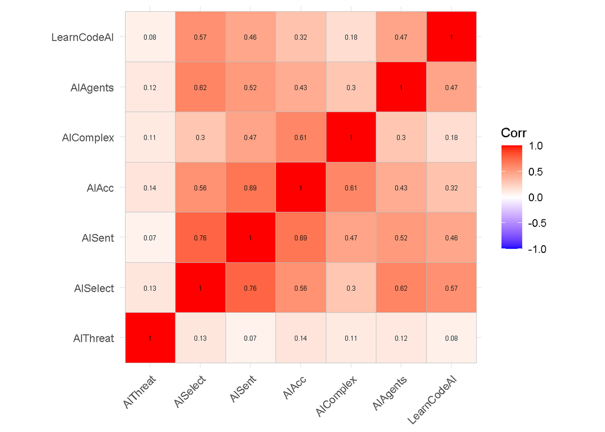

```r
poly_matrix <- polychoric(df_efa)
ggcorrplot(poly_matrix$rho,lab=TRUE,tl.cex=9,lab_size=2)
```

Wykorzystanie macierzy korelacji polichorycznych pozwoliło na rzetelną kwantyfikację relacji między zmiennymi porządkowymi, co jest kluczowe dla poprawności statystycznej modeli opartych na skalach porządkowych. W strukturze macierzy zidentyfikowano wyraźną agregację kluczowych konstruktów zaufania do dokładności AI, stosunku do używania AI oraz radzenia sobie AI ze złożonymi zadaniami.

**Test sferyczności Bartletta**

```r
cortest.bartlett(poly_matrix$rho, n = nrow(df))
```

```
## $chisq
## [1] 61485.94
##
## $p.value
## [1] 0
##
## $df
## [1] 21
```

Ostatnim krokiem weryfikującym zasadność przeprowadzenia EFA jest test sferyczności Bartletta, którego wyniki stanowią statystyczne potwierdzenie dla wcześniej zaobserwowanych korelacji w macierzy polichorycznej. Test ten służy do zweryfikowania hipotezy zerowej, która zakłada, że macierz korelacji jest macierzą jednostkową.

Wyniki przeprowadzonego badania dostarczają bardzo silnych dowodów na korzyść modelowania czynnikowego. Wskaźnik p-value wynosi 0, pozwala to na odrzucenie hipotezy zerowej. Wynik stanowi potwierdzenie, że zmienne w zbiorze danych są ze sobą istotnie skorelowane.

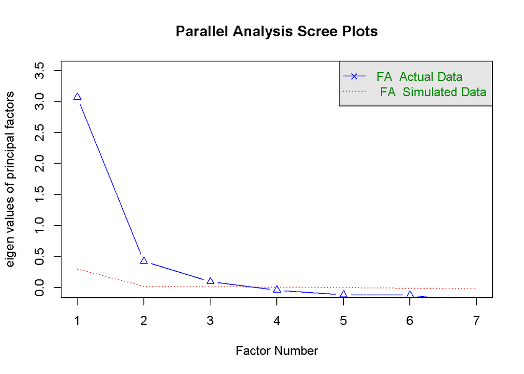

```
## Parallel analysis suggests that the number of factors =  3  and the number of components =  NA
```

```r
fa.parallel(poly_matrix$rho, n.obs = nrow(df_efa), fa = "fa")
```

Kolejnym krokiem przed przystąpieniem do ostatecznej rotacji czynników jest analiza równoległa. Jest to jedna z najbardziej obiektywnych metod wyznaczania liczby czynników, które należy zatrzymać w modelu EFA. W modelu EFA zatrzymujemy tylko te czynniki, dla których wartości własne z danych rzeczywistych znajdują się powyżej linii danych symulowanych. Na podstawie analizy przebiegu obu linii na wykresie, można sformułować następujący wniosek, że istnieje konieczność wyodrębnienia 3 czynników.

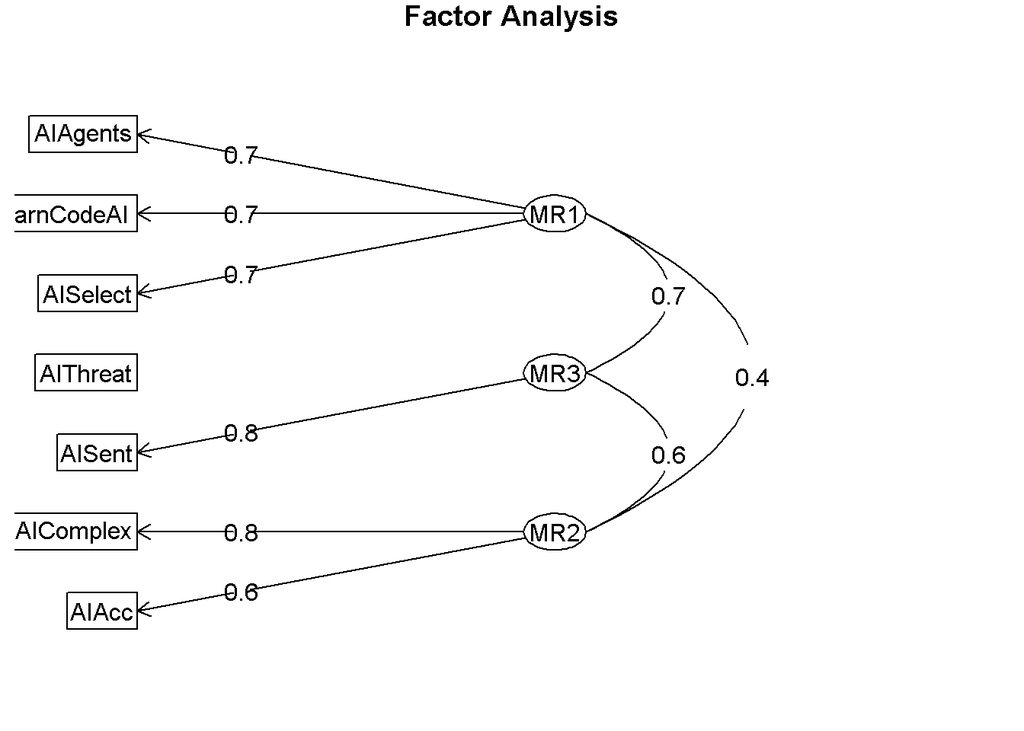

```r
efa_result <- fa(poly_matrix$rho,
                 nfactors = 3,
                 n.obs = nrow(df_efa),
                 rotate = "oblimin",
                 fm = "minres")


fa.diagram(efa_result)
```

```r
print(efa_result$loadings, cutoff = 0.3)
```

```
##
## Loadings:
##             MR1    MR3    MR2
## AIThreat
## AISelect     0.657  0.342
## AISent              0.846
## AIAcc               0.301  0.565
## AIComplex                  0.811
## AIAgents     0.739
## LearnCodeAI  0.682
##
##                  MR1   MR3   MR2
## SS loadings    1.506 0.973 1.041
## Proportion Var 0.215 0.139 0.149
## Cumulative Var 0.215 0.354 0.503
```

Wyniki Eksploracyjnej Analizy Czynnikowej pozwalają na wyodrębnienie trzech głównych wymiarów, które tłumaczą łącznie 50,3% całkowitej wariancji postaw deweloperów wobec AI.

**Czynnik MR1: Adopcja AI** (21,5% wariancji)

Jest to najsilniejszy wymiar, który grupuje zmienne związane z aktywnym wdrażaniem AI do codziennego warsztatu pracy oraz inwestowaniem czasu w naukę tych technologii. Najwyższe ładunki posiadają AIAgents (0,739) oraz LearnCodeAI (0,682), wspierane przez AISelect (0,657).

**Czynnik MR2: Ocena AI** (14,9% wariancji)

Wymiar ten koncentruje się na technicznym zaufaniu do jakości wyników dostarczanych przez sztuczną inteligencję. Dominuje tu zmienna AIComplex (0,811) oraz AIAcc (0,565).

**Czynnik MR3: Entuzjazm do AI** (13,9% wariancji)

Ostatni czynnik ma charakter bardziej subiektywny i emocjonalny, opisując ogólny stosunek dewelopera do nowej fali technologicznej. Najsilniejszy ładunek ma zmienna AISent (0,846) Znacznie słabsze powiązanie wykazują zmienne AISelect (0,342) oraz AIAcc (0,301).

Warto zwrócić uwagę, że zmienna dotycząca lęku przed AI nie uzyskała istotnego ładunku w żadnym z czynników. Potwierdza to wcześniejsze obserwacje z macierzy korelacji.

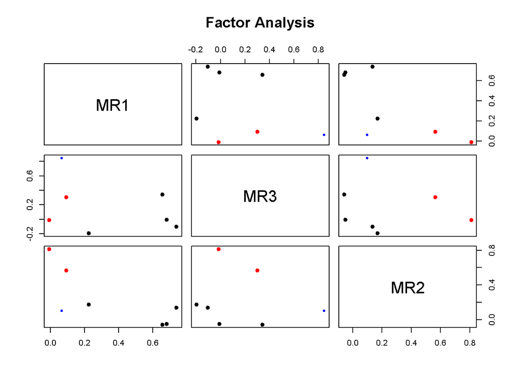

```r
fa.plot(efa_result)
```

Wykres stanowi wizualną mapę ładunków czynnikowych, przedstawiając rozmieszczenie badanych zmiennych w przestrzeni trzech wyodrębnionych wymiarów MR1, MR2 oraz MR3. Kropki reprezentujące poszczególne zmienne są wyraźnie pogrupowane wzdłuż osi czynników. Oznacza to, że większość pytań silnie definiuje tylko jeden konkretny wymiar, nie wykazując przy tym kłopotliwych, silnych ładunków krzyżowych. Na wykresie MR1 widać wyraźne wysunięcie zmiennych związanych z zaawansowaną adopcją, takich jak agenci AI, podczas gdy na osi MR3 dominuje odosobniony punkt odpowiadający ogólnemu nastawieniu. Na wykresach korelujących z MR2 widać skupienie punktów dotyczących zaufania i złożoności technicznej, które wyraźnie oddzielają się od sfery czysto emocjonalnej MR3 czy edukacyjnej MR1.

# 7. Porównanie metod

```r
# Zestawienie wyników EFA i HCPC


zmienne_efa <- rownames(efa_result$loadings)
dane_do_wynikow <- df_efa[, zmienne_efa]

scores_obj <- factor.scores(dane_do_wynikow, efa_result, method = "tenBerge")
fa_scores <- as.data.frame(scores_obj$scores)
fa_scores$SurveyID <- rownames(fa_scores)


clusters_df <- res.hcpc$data.clust
clusters_df$SurveyID <- rownames(clusters_df)


df_combined <- merge(clusters_df, fa_scores, by = "SurveyID")


levels(df_combined$clust) <- c(
  "1" = "Ekosystem Microsoft",
  "2" = "Backend",
  "3" = "Frontend",
  "4" = "Klasyczne Systemy Internetowe",
  "5" = "Zarządzanie bazami danych MS",
  "6" = "Złożone systemy biznesowe (Java)",
  "7" = "Przetwarzanie w Czasie Rzeczywistym",
  "8" = "Nowoczesne aplikacje pełnowymiarowe",
  "9" = "Inżynieria niskopoziomowa",
  "10" = "Technologie eksperymentalne"
)


zmienne_extra <- df[, c("WorkExp", "JobSat", "EdLevel", "AIThreat")]
zmienne_extra$SurveyID <- rownames(zmienne_extra)

df_combined <- merge(df_combined, zmienne_extra, by = "SurveyID", all.x = TRUE)


profil_postaw <- df_combined %>%
  group_by(clust) %>%
  summarise(
    MR1_UzycieAI = mean(MR1, na.rm = TRUE),
    MR2_EntuzjazmAI = mean(MR2, na.rm = TRUE),
    MR3_OcenaAI = mean(MR3, na.rm = TRUE),
    StrachAI = mean(AIThreat, na.rm = TRUE),
    Doswiadczenie = mean(WorkExp, na.rm = TRUE),
    Satysfakcja = mean(JobSat, na.rm = TRUE),
    Edukacja = mean(EdLevel, na.rm = TRUE)
  )
```

```r
# Tabela końcowa
tabela_do_druku <- profil_postaw %>%
  mutate(across(where(is.numeric), ~ round(.x, 3)))

tabela_do_druku %>%
  kable(
    format = "html",
    col.names = c("Profil (Klaster)", "MR1 - Adopcja AI", "MR2 - Ocena AI", "MR3 - Entuzjazm do AI",
                  "Strach", "Doświadczenie", "Satysfakcja", "Edukacja"),
    align = "lcccccccc",
    caption = "Profil postaw wobec AI"
  ) %>%
  kable_styling(
    bootstrap_options = c("striped", "hover", "condensed"),
    full_width = F,
    position = "center"
  ) %>%
  row_spec(0, bold = TRUE, color = "white", background = "#F48024") %>%
  column_spec(1, bold = T, color = "#F48024")
```

Profil postaw wobec AI

| Profil (Klaster) | MR1 - Adopcja AI | MR2 - Ocena AI | MR3 - Entuzjazm do AI | Strach | Doświadczenie | Satysfakcja | Edukacja |
| --- | --- | --- | --- | --- | --- | --- | --- |
| Ekosystem Microsoft | -0.006 | -0.017 | 0.009 | 0.462 | 2.736 | 2.867 | 4.817 |
| Backend | 0.014 | 0.065 | 0.005 | 0.501 | 2.529 | 2.828 | 5.050 |
| Frontend | -0.012 | -0.015 | -0.004 | 0.539 | 2.151 | 2.822 | 4.807 |
| Klasyczne Systemy Internetowe | -0.017 | -0.011 | -0.004 | 0.503 | 2.614 | 2.832 | 4.560 |
| Zarządzanie bazami danych MS | -0.057 | -0.070 | -0.068 | 0.430 | 2.642 | 2.868 | 4.657 |
| Złożone systemy biznesowe (Java) | -0.066 | -0.034 | -0.034 | 0.458 | 2.245 | 2.846 | 4.933 |
| Przetwarzanie w Czasie Rzeczywistym | 0.008 | -0.010 | 0.025 | 0.435 | 2.502 | 2.949 | 4.588 |
| Nowoczesne aplikacje pełnowymiarowe | -0.019 | -0.008 | -0.032 | 0.499 | 2.108 | 2.874 | 4.613 |
| Inżynieria niskopoziomowa | -0.101 | 0.042 | -0.061 | 0.456 | 2.380 | 2.771 | 4.821 |
| Technologie eksperymentalne | 0.025 | -0.402 | -0.065 | 1.083 | 2.333 | 3.000 | 4.800 |

Powyższa tabela stanowi ostateczną syntezę całego procesu badawczego, rzutując wyniki czynnikowe postaw na wyodrębnione ekosystemy technologiczne. Te dane operują na wynikach czynnikowych wyśrodkowanych wokół zera oraz średnich punktowych dla pozostałych metryk, co pozwala na bardzo precyzyjną diagnostykę różnic między grupami deweloperów.

# 8. Wnioski z analizy

Mimo uzyskania statystycznie spójnego modelu, należy wskazać na istotne ograniczenia metodologiczne, które rzutują na interpretację końcowych wyników. W sferze diagnostyki EFA wyzwaniem okazała się niska adekwatność zmiennej doświadczenia zawodowego, której wynik MSA na poziomie 0,35 sugeruje, że nie wpisywała się ona optymalnie w strukturę wymiarów postaw i mogła wprowadzać szum informacyjny. Ponadto, mimo zastosowania zaawansowanej imputacji braków danych, zmienna satysfakcji zawodowej charakteryzowała się wysokim odsetkiem brakujących wartości, co mogło wpłynąć na precyzję estymacji dobrostanu w najmniej licznych klastrach. Ograniczeniem analizy MCA była z kolei niska suma wyjaśnianej wariancji przez dwa główne wymiary, wynosząca łącznie 11%, co obrazuje ogromne rozdrobnienie nowoczesnego rynku technologicznego, którego nie da się w pełni sprowadzić do prostego układu osi bez utraty części szczegółów. Całość badania opiera się na deklaratywnym charakterze odpowiedzi w skalach Likerta, co przy tak polaryzującej technologii jak AI naraża wyniki na błędy wynikające z subiektywizmu.